# R Notebook

# T Test Normality

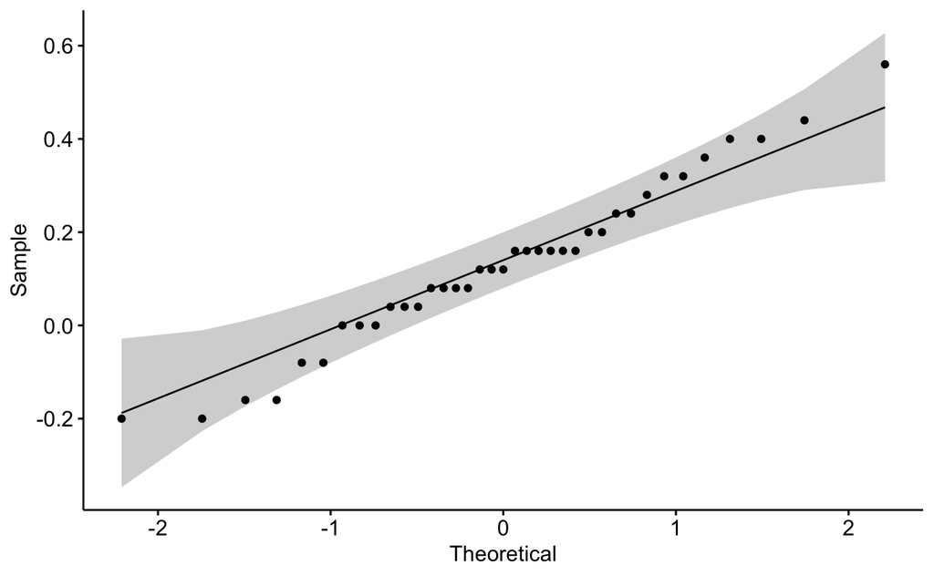

```r
ggqqplot(subject_accuracy_wide, "mean_difference")
```

```r
subject_accuracy_wide %>% shapiro_test(mean_difference)
```

| variable | statistic | p |
| --- | --- | --- |
| mean_difference | 0.9787041 | 0.6864971 |

The normality assumption is satisfied because p > .05, so there is no significance difference between our distribution and the normal distribution.

# Overall Pattern Interpretation

We have satisfied the assumptions about outliers and normality, so the t-test value is valid. This means that, on average, phonological cues help people to retrieve words more accurately than semantic cues.

# Plot RTs

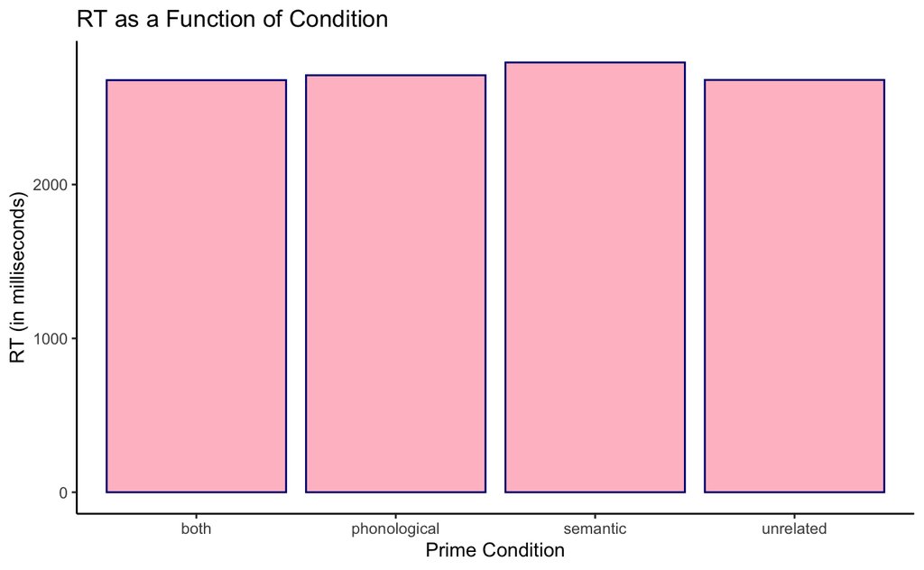

```r
mean_rt = subject_rt %>%
  group_by(prime_condition) %>%
  summarise(mean_rt = mean(mean_RT))

mean_rt %>%
  ggplot(aes(x = prime_condition, y = mean_rt)) +
  geom_col(fill = "pink", color = "navy")+
  theme_classic()+
  xlab("Prime Condition") +
  ylab ("RT (in milliseconds)")+
  ggtitle("RT as a Function of Condition")
```

# T-Test for RTs

```r
subject_rt_wide = subject_rt %>%
  pivot_wider(names_from = prime_condition, values_from = mean_RT)

subject_rt_wide = subject_rt_wide %>%
  mutate(mean_rt_diff = semantic - both)

subject_rt_wide = subject_rt_wide %>% ungroup()

rt_outliers = subject_rt_wide %>%
  identify_outliers(mean_rt_diff)

subject_rt_wide %>% shapiro_test(mean_rt_diff)
```

| variable | statistic | p |
| --- | --- | --- |
| mean_rt_diff | 0.9727757 | 0.4886474 |

```r
t.test(subject_rt_wide$semantic, subject_rt_wide$both, var.equal = FALSE, paired = TRUE)
```

```
    Paired t-test

data:  subject_rt_wide$semantic and subject_rt_wide$both
t = 1.1348, df = 36, p-value = 0.264
alternative hypothesis: true mean difference is not equal to 0
95 percent confidence interval:
 -90.67728 321.04701
sample estimates:
mean difference
       115.1849
```

If we again assume a two-tailed test, we compare our p value of 0.264 to 0.025 and find that there is no significant difference in the mean RT between the “semantic” and “both” prime conditions.